# Gustavo Diaz – maple24

## The Merits of Externally Invalid Survey Experiments

**Gustavo Diaz**  
McMaster University  
[gustavodiaz.org](https://gustavodiaz.org/)  
diazg2@mcmaster.ca

Slides: [gustavodiaz.org/talk](https://gustavodiaz.org/talk.html)

## Limitations

“Future research should confirm if our findings generalize…”

- …with a representative sample
- …in other countries
- …beyond the survey setting
- …when using behavioral outcomes

## Usual workflow

1. Research idea
2. Realize resource/ethical/practical limitations
3. Conduct experiment with limitations
4. Wave hands about external validity

## Recent trends

## Recent trends

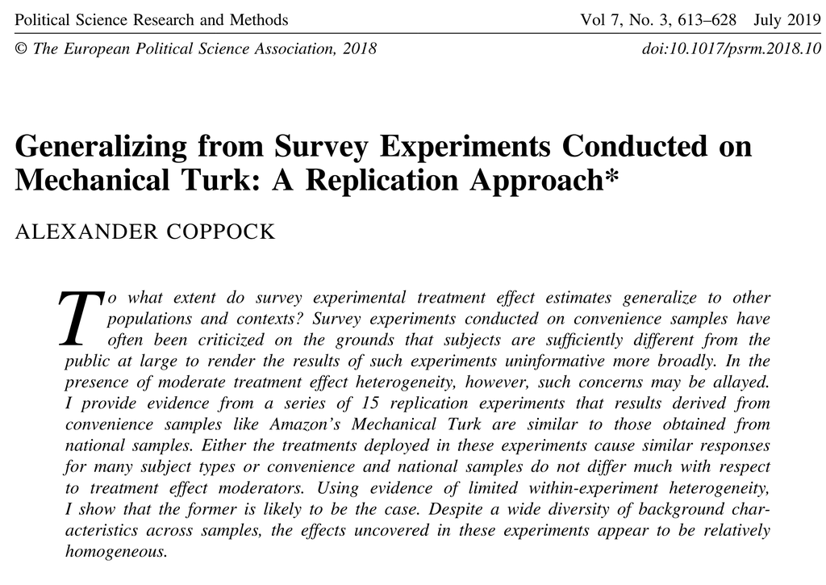

## Recent trends

[figure not shown]

## Goal

- Should we ever implement an externally invalid survey experiment **on purpose**?
- Identify what makes external invalidity *desirable*
- **Challenge:** Different kinds of external (in)validity

## External validity concerns

| Type | Concern |
| --- | --- |
| Samples | Does this apply to a different population? |
| Contexts | Does this apply in a different setting? |
| Treatments | Do they resemble real-world phenomena? |
| Outcomes | Do they reflect actual behaviors? |

See [Shadish et al (2002)](https://psycnet.apa.org/record/2002-17373-000) and [Egami and Hartmant (2023)](https://doi.org/10.1017/S0003055422000880) for details

## External validity concerns

| Type | Concern |
| --- | --- |
| Samples | Does this apply to a different population? |
| Contexts | Does this apply in a different setting? |
| Treatments | Do they resemble real-world phenomena? |
| Outcomes | Do they reflect actual behaviors? |

See [Shadish et al (2002)](https://psycnet.apa.org/record/2002-17373-000) and [Egami and Hartmant (2023)](https://doi.org/10.1017/S0003055422000880) for details

## External validity concerns

| Type | Concern |
| --- | --- |
| Samples | Does this apply to a different population? |
| Contexts | Does this apply in a different setting? |
| Treatments | Do they resemble real-world phenomena? |
| Outcomes | Do they reflect actual behaviors? |

See [Shadish et al (2002)](https://psycnet.apa.org/record/2002-17373-000) and [Egami and Hartmant (2023)](https://doi.org/10.1017/S0003055422000880) for details

## External validity concerns

| Type | Concern |
| --- | --- |
| Samples | Does this apply to a different population? |
| Contexts | Does this apply in a different setting? |
| Treatments | Do they resemble real-world phenomena? |
| Outcomes | Do they reflect actual behaviors? |

See [Shadish et al (2002)](https://psycnet.apa.org/record/2002-17373-000) and [Egami and Hartmant (2023)](https://doi.org/10.1017/S0003055422000880) for details

## External validity concerns

| Type | Concern |
| --- | --- |
| Samples | Does this apply to a different population? |
| Contexts | Does this apply in a different setting? |
| Treatments | Do they resemble real-world phenomena? |
| Outcomes | Do they reflect actual behaviors? |

See [Shadish et al (2002)](https://psycnet.apa.org/record/2002-17373-000) and [Egami and Hartmant (2023)](https://doi.org/10.1017/S0003055422000880) for details

# Examples

## Samples

[figure not shown]

## Samples

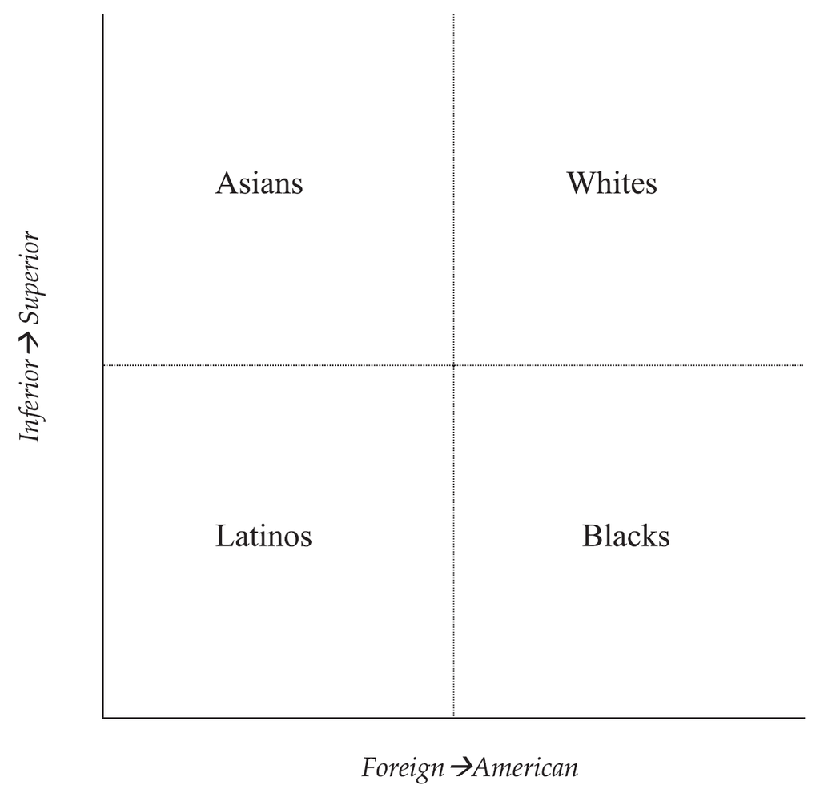

## Contexts

[figure not shown]

## Contexts

*Saudi Arabia and Kuwait were selected for their theoretical case value;*

## Contexts

*Saudi Arabia and Kuwait were selected for their theoretical case value; both are high in gender inegalitarianism, and they offer tough tests.*

## Contexts

*Saudi Arabia and Kuwait were selected for their theoretical case value; both are high in gender inegalitarianism, and they offer tough tests. In addition, while these neighboring countries have much in common, both resource-rich and highly conservative, they also differ in important ways.*

## Contexts

*Saudi Arabia and Kuwait were selected for their theoretical case value; both are high in gender inegalitarianism, and they offer tough tests. In addition, while these neighboring countries have much in common, both resource-rich and highly conservative, they also differ in important ways. Thus, if similar results are found, the case for generalizability across different interaction types and varying national circumstances will be strengthened.*

## Treatments

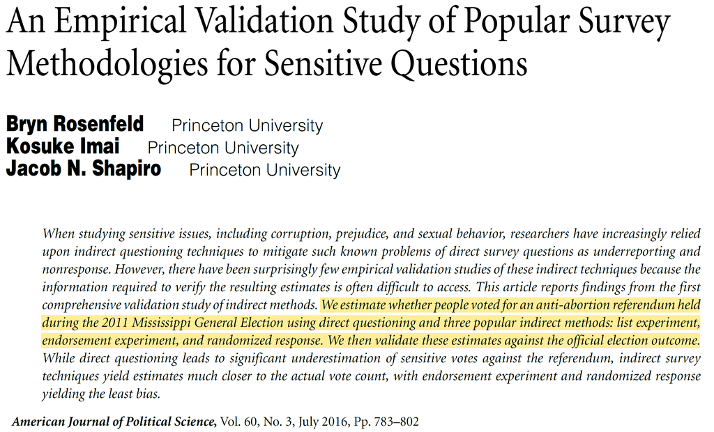

## Treatments

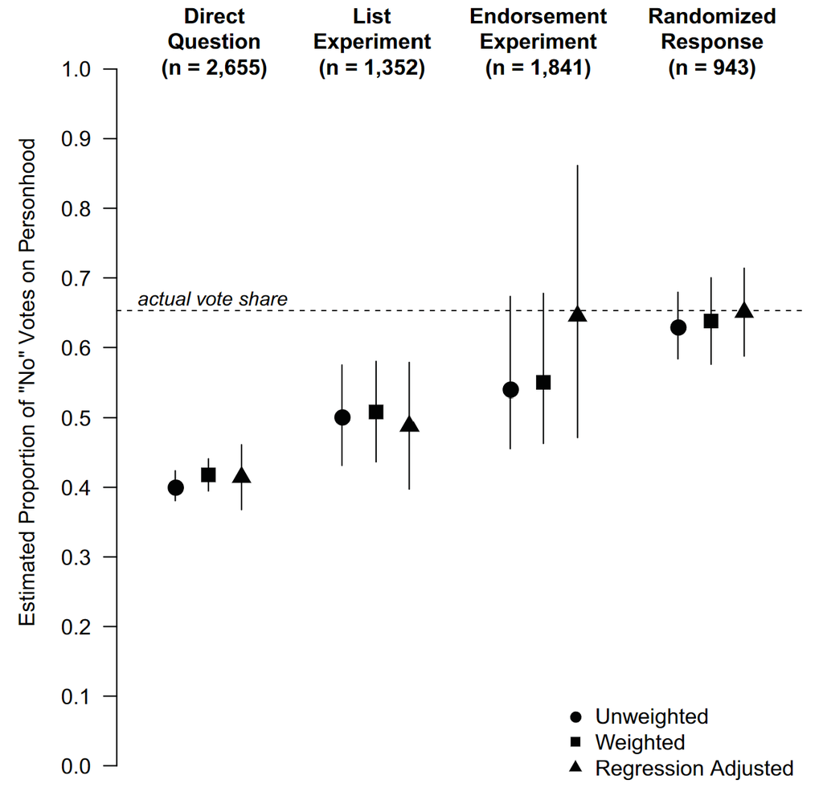

## Outcomes

[figure not shown]

## Outcomes

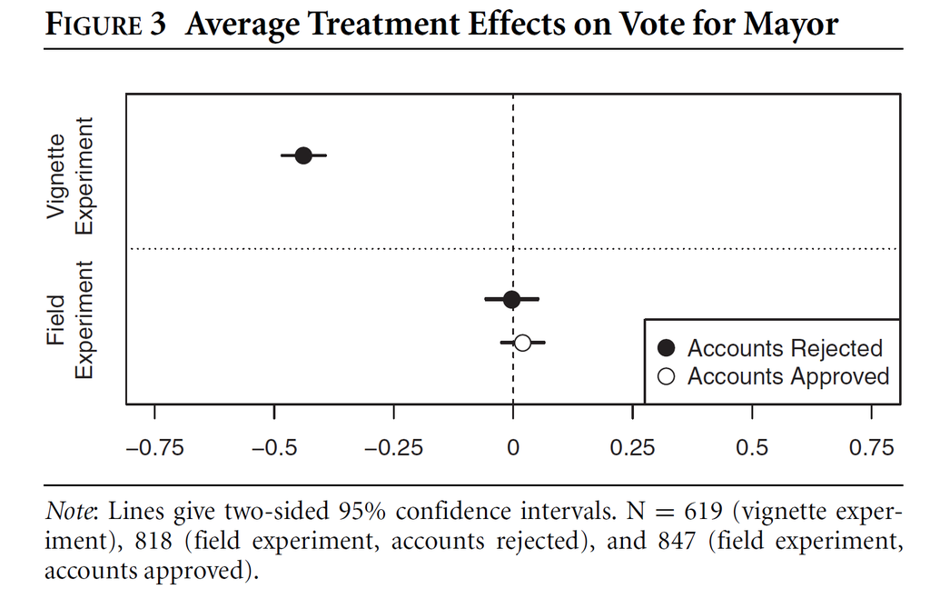

## Conclusion

| Invalid | Benefit |
| --- | --- |
| Samples | Contour generalizations |
| Contexts | Contour generalizations |
| Treatments | Statistical properties |
| Outcomes | Hypothetical/rare scenarios |

- **Endline:** Consider merits before implementation
- What would persuade **you** to embrace external invalidity?

**Learn more:** [gustavodiaz.org](https://gustavodiaz.org/)